# Analysis of San Francisco Salaries (2011-2014)

**Introduction**

In this Python script, I am taking a deep dive into a dataset that reveals the salaries of San Francisco city employees from 2011 to 2014. The dataset, named 'SFSalaries2011_2014.csv,' gets loaded into a Pandas DataFrame, essentially a digital table that makes it easy for us to work with the data. This DataFrame becomes our home base for exploring various aspects of the dataset using numbers, charts, and targeted questions.

Once the dataset is loaded, my exploration kicks off with a focus on basic numerical insights. I start by examining straightforward statistics like average pay and the distribution of salaries, aiming to grasp the fundamental characteristics of the compensation landscape. This numerical analysis provides us with a quantitative lens to identify trends, variations, and significant observations within the dataset.

This script not only uncovers the San Francisco city employee salaries over the four-year period but also serves as a demonstration of the capabilities of Python, Pandas, and related tools in the realm of data exploration. Through a blend of simple language, numerical analyses, and compelling visuals, my script try to show the narrative work into the salary data, contributing to a comprehensive understanding during this specific time frame.

**Imports**

In this Python script, I begin by importing essential libraries for data manipulation and visualization. The `pandas` library, reduced as `pd`, empowers us with powerful tools for handling and analyzing datasets. For crafting visualizations, we bring in `matplotlib.pyplot` and leverage the aesthetics of data visualization with the `seaborn` library, aliased as `sns`.

```python
import pyspark
import pandas as pd
import matplotlib.pyplot as plt
import seaborn as sns
```

**Code Overview**

Loading the Dataset: The script begins by importing the necessary libraries - Pandas for data manipulation and analysis, Matplotlib for plotting, and Seaborn for enhanced data visualization. The dataset is then loaded into a Pandas DataFrame named 'df' using the read_csv function.

```python
df = pd.read_csv('/storage/home/sjk6402/DS220/SFSalaries2011_2014.csv')
```

**Basic Statistics and Distribution Plot**

Descriptive statistics of the dataset are displayed using the describe function. Additionally, a histogram with a kernel density estimate (KDE) is generated to visualize the distribution of 'TotalPay'.

```python
# Display basic statistics
print(df.describe())
```

```
                  Id       TotalPay  TotalPayBenefits           Year  Notes
count  148654.000000  148654.000000     148654.000000  148654.000000    0.0
mean    74327.500000   74768.321972      93692.554811    2012.522643    NaN
std     42912.857795   50517.005274      62793.533483       1.117538    NaN
min         1.000000    -618.130000       -618.130000    2011.000000    NaN
25%     37164.250000   36168.995000      44065.650000    2012.000000    NaN
50%     74327.500000   71426.610000      92404.090000    2013.000000    NaN
75%    111490.750000  105839.135000     132876.450000    2014.000000    NaN
max    148654.000000  567595.430000     567595.430000    2014.000000    NaN
```

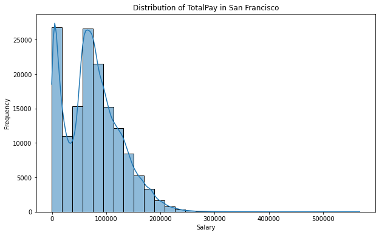

```python
# Distribution plot of salaries
plt.figure(figsize=(10, 6))
sns.histplot(df['TotalPay'], bins=30, kde=True)
plt.title('Distribution of TotalPay in San Francisco')
plt.xlabel('Salary')
plt.ylabel('Frequency')
plt.show()
```

**Questions for analyzing the data**

1. What constitutes the average salary (TotalPay) in San Francisco?
2. Among job titles, which ones command the highest and lowest average salaries (TotalPay)?
3. Identify job titles whose salaries (TotalPay) closely align with the mean salary (TotalPay)?
4. Is there a discernible correlation between the number of years of experience and total pay?
5. In what manner does total pay exhibit variations across different years?
6. How the distribution of base pay, overtime pay, and other pay components contributes to the overall total pay?
7. What is the top 5 highest-paid employees?

# Map Questions to Queries on the Pandas Dataframe

**Average Salary Calculation**

The average salary ('TotalPay') across all employees is calculated and printed.

```python
# 1.
average_salary = df['TotalPay'].mean()
print("The average salary(TotalPay) in San Francisco: ", average_salary)
print()
```

```
The average salary(TotalPay) in San Francisco:  74768.321971703
```

**Highest and Lowest Average Salaries by Job Title**

The script identifies the job titles with the highest and lowest average salaries and prints the results.

```python
# 2.
highest_salary_job = df.groupby('JobTitle')['TotalPay'].mean().idxmax()
lowest_salary_job = df.groupby('JobTitle')['TotalPay'].mean().idxmin()
print("The highest average salaries in San Francisco: ", highest_salary_job)
print("The lowest average salaries in San Francisco: ", lowest_salary_job)
print()
```

```
The highest average salaries in San Francisco:  GENERAL MANAGER-METROPOLITAN TRANSIT AUTHORITY
The lowest average salaries in San Francisco:  Drug Court Coordinator
```

**Job Titles with Salaries Similar to the Overall Mean**

Job titles with salaries close to the overall mean are determined based on a defined tolerance level.

```python
# 3
overall_mean_salary = df['TotalPay'].mean()
tolerance = 5 # Define a tolerance level for similarity

similar_job_titles = df[
    (df['TotalPay'] >= overall_mean_salary - tolerance) &
    (df['TotalPay'] <= overall_mean_salary + tolerance)
]['JobTitle'].unique() # Filter job titles with total pay similar to the overall mean

print("Job titles with similar to the overall mean:")
print(similar_job_titles)
print()
```

```
Job titles with similar to the overall mean:
['PUBLIC SAFETY COMMUNICATIONS DISPATCHER' 'ELIGIBILITY WORKER SUPERVISOR'
 'Patient Care Assistant' 'Gardener' 'Executive Secretary 3'
 'Community Police Services Aide' 'Marine Engineer of Fire Boats'
 'Health Care Billing Clerk 2']
```

**Correlation Between Years of Experience and Total Pay**

The correlation coefficient between the 'Year' and 'TotalPay' columns is calculated and printed.

```python
# 4
correlation_experience_total_pay = df['Year'].corr(df['TotalPay'])
print("The correlation between years of experience and total pay: ", correlation_experience_total_pay)
print()
```

```
The correlation between years of experience and total pay:  0.032090397985590435
```

**Total Pay Variation Across Different Years**

The average total pay is calculated for each year, providing insights into how salaries vary over time.

```python
# 5
total_pay_over_years = df.groupby('Year')['TotalPay'].mean()
print("The total pay vary across different years: ")
print(total_pay_over_years)
print()
```

```
The total pay vary across different years:
Year
2011    71744.103871
2012    74113.262265
2013    77611.443142
2014    75463.918140
Name: TotalPay, dtype: float64
```

**Distribution of Salary Components**

```python
# 6
pay_distribution = df[['BasePay', 'OvertimePay', 'OtherPay', 'TotalPay']].describe()
print("The distribution of base pay, overtime pay, and other pay contribute to the total pay: ")
print(pay_distribution)
```

```
The distribution of base pay, overtime pay, and other pay contribute to the total pay:
            TotalPay
count  148654.000000
mean    74768.321972
std     50517.005274
min      -618.130000
25%     36168.995000
50%     71426.610000
75%    105839.135000
max    567595.430000
```

**Highest-Paid Employees**

Identify the top 5 highest-paid employees

```python
# 7
highest_paid_employees = df.nlargest(5, 'TotalPay')
print("Top 5 highest-paid employees:")
print(highest_paid_employees[['EmployeeName', 'TotalPay']])
print()
```

```
Top 5 highest-paid employees:
          EmployeeName   TotalPay
0       NATHANIEL FORD  567595.43
1         GARY JIMENEZ  538909.28
110531     David Shinn  471952.64
110532      Amy P Hart  390111.98
36159   Gary Altenberg  362844.66
```

# Additional Visualizations

**Box plot of TotalPay across years**

The script uses Seaborn and Matplotlib to create a boxplot showing TotalPay distribution across years in San Francisco.

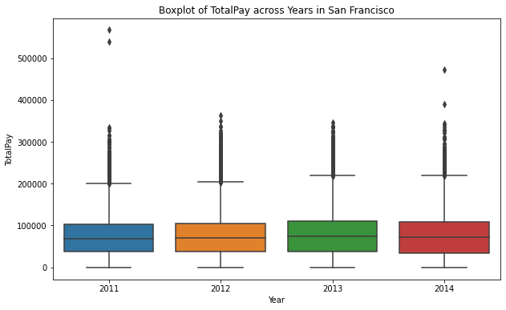

```python
plt.figure(figsize=(10, 6))
sns.boxplot(x='Year', y='TotalPay', data=df)
plt.title('Boxplot of TotalPay across Years in San Francisco')
plt.xlabel('Year')
plt.ylabel('TotalPay')
plt.show()
```

**Exploration of Job Titles and Top Job Titles**

Recognizing the significance of job titles, the script takes time to spotlight them. It prints unique job titles found in the dataset, providing a diversity of roles. Additionally, it shows a bar plot illustrating the average TotalPay for the top 10 job titles, adding depth to the understanding of salary differentials

```
Unique Job Titles in the dataset:
['GENERAL MANAGER-METROPOLITAN TRANSIT AUTHORITY'
 'CAPTAIN III (POLICE DEPARTMENT)' 'WIRE ROPE CABLE MAINTENANCE MECHANIC'
 ... 'Conversion' 'Cashier 3' 'Not provided']
```

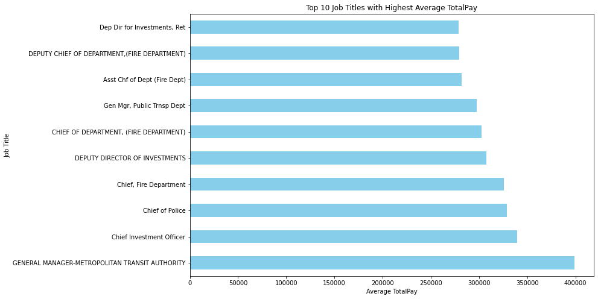

```python
# Print unique job titles in the dataset
unique_job_titles = df['JobTitle'].unique()
print("Unique Job Titles in the dataset:")
print(unique_job_titles)
print()

# Bar plot of the average TotalPay for the top 10 Job Titles
top_job_titles = df.groupby('JobTitle')['TotalPay'].mean().nlargest(10)
plt.figure(figsize=(12, 8))
top_job_titles.plot(kind='barh', color='skyblue')
plt.title('Top 10 Job Titles with Highest Average TotalPay')
plt.xlabel('Average TotalPay')
plt.ylabel('Job Title')
plt.show()
```

**Displaying a bar plot of the average TotalPay for the bottom 10 Job Titles**

This code calculates the mean TotalPay for job titles, selects the bottom 10, and creates a horizontal bar plot to visualize them.

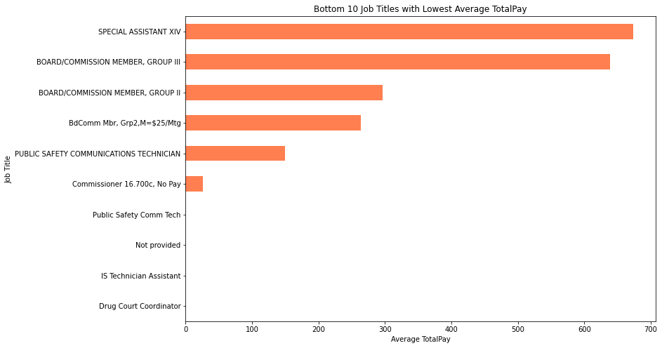

```python
bottom_job_titles = df.groupby('JobTitle')['TotalPay'].mean().nsmallest(10)
plt.figure(figsize=(12, 8))
bottom_job_titles.plot(kind='barh', color='coral')
plt.title('Bottom 10 Job Titles with Lowest Average TotalPay')
plt.xlabel('Average TotalPay')
plt.ylabel('Job Title')
plt.show()
```

# Derive Insights

        Mean: $74,768.32

        Standard Deviation: $50,517.01

        Minimum: -$618.13

        25th Percentile: $36,168.99

        Median (50th Percentile): $71,426.61

        75th Percentile: $105,839.14

        Maximum: $567,595.43
   ```

7. Top 5 highest-paid employees (7):

   ```
        Top 5 highest-paid employees:

        EmployeeName   TotalPay

        NATHANIEL FORD  567595.43

        GARY JIMENEZ  538909.28

        David Shinn  471952.64

        Amy P Hart  390111.98

        Gary Altenberg  362844.66
   ```

In summary, these insights provide a comprehensive view of San Francisco's compensation landscape, from job title variance and correlations with experience to temporal trends and the nuanced breakdown of total pay components. The numeric indicators serve as guideposts, facilitating a short understanding of the dataset's key dynamics.

# Communicating Insights

# Conclusion

Exploring these findings helps me understand what factors influence salaries in San Francisco. This knowledge is useful for people making career decisions and for companies improving how they pay employees.

Knowing how salaries work in San Francisco is helpful for both individuals and companies. For individuals, this knowledge helps with making smart career decisions, like negotiating a job offer or figuring out how to move up in a career. Understanding the important factors that determine pay allows individuals to match their skills, experience, and expectations with what salaries are like in their field.

For companies, these insights can be used to make pay strategies better. Knowing the average salary, differences in pay for different jobs, and the connection between experience and pay can help companies set fair and competitive pay structures. This is especially important for getting top talent, keeping skilled employees, and making sure pay is fair within the company.

Looking at jobs that are close to the average total pay gives an idea of what jobs have salaries similar to the average in San Francisco. For people looking for jobs with salaries like what the city usually pays, these job titles can be useful guides. They show jobs that typically offer pay close to what is considered normal in the city, helping people in their job search.

Seeing how total pay changes over different years gives a peek into how salaries change. Knowing these ups and downs can be helpful for people planning their careers. For example, understanding which years had the highest total pay might influence decisions about changing jobs or negotiating salaries at certain times.

In summary, these insights are like a helpful guide for both individuals and companies dealing with the complicated world of pay in San Francisco. For individuals, it gives direction in making smart career choices that match salary trends. For companies, it provides a useful tool to make pay structures better, ensuring fairness and competitiveness. Overall, this understanding makes the job world clearer and helps create positive results for both workers and employers.